# Final Project

## Part II: Algorithmic Thinking

### Objective

In this portion of the assignment, our goal is to predict the value of a new single-family property given comparable sales data. One way we might estimate the value of a home is to look at the value of *k*-similar nearby homes that have recently sold. The average sales price of those *k* homes could then be used as the predicted valuation for our new home. This process is effectively how the K-Nearest Neighbor Algorithm (KNN) works for regression problems.

KNN is considered a supervised machine learning algorithm that can be used to solve both classification and regression problems. As shown above, we can be used to solve nonparametric regression problems such as predicting the price of a new home based on *similar* nearby homes.

Recall the central factors used for property valuation:

- Location
- Living Area (SQFT)
- Age of the Home
- Finished Basement

### 2.0 Read and Prepare the Sales Data (15 pts)

Tasks:

- Load the sales.csv
- Keep only qualified sales (sales.sales_cd == 'Q') and sales.price > 0.
- Keep only sales in the last 5 years (01/01/2015 and 12/31/2020)
- Join "sales" with the necessary data frames to add the following columns
  - nh, this is the neighborhood number that must be used to identify comparable sales by location.
  - totalActualVal
  - builtYear
  - EffectiveYear
  - TotalFinishedSF
  - A boolean flag (1/0) for if the basement is finished that you will need to create

# Part II: Algorithmic Thinking - Solution

## 2.0 Read and Prepare the Sales Data

### 2.0-1 Load sales.csv file

```python
sales_df = pd.read_csv("..\\data-sets\\sales.csv")
sales_df.head(5)
```

|  | strap | deedNum | Tdate | sales_cd | deed_type | price | status_cd |
| --- | --- | --- | --- | --- | --- | --- | --- |
| 0 | R0000005 | 416158 | 10/7/1980 12:00:00 AM | Q | WJ | 89500.0 | A |
| 1 | R0000005 | 1317705 | 7/26/1993 12:00:00 AM | Q | WD | 149900.0 | A |
| 2 | R0000005 | 2316275 | 7/18/2002 12:00:00 AM | Q | WD | 345000.0 | A |
| 3 | R0000005 | 2316274 | 7/30/2002 12:00:00 AM | Q | WD | 345000.0 | A |
| 4 | R0000006 | 864603 | 11/27/1967 12:00:00 AM | U | QD | NaN | A |

### 2.0-2 Keep only qualified sales (sales.sales_cd == 'Q') and sales.price > 0

```python
qualified_sales_df = sales_df[((sales_df.sales_cd == 'Q') & (sales_df.price > 0))]
qualified_sales_df.head(5)
```

|  | strap | deedNum | Tdate | sales_cd | deed_type | price | status_cd |
| --- | --- | --- | --- | --- | --- | --- | --- |
| 0 | R0000005 | 416158 | 10/7/1980 12:00:00 AM | Q | WJ | 89500.0 | A |
| 1 | R0000005 | 1317705 | 7/26/1993 12:00:00 AM | Q | WD | 149900.0 | A |
| 2 | R0000005 | 2316275 | 7/18/2002 12:00:00 AM | Q | WD | 345000.0 | A |
| 3 | R0000005 | 2316274 | 7/30/2002 12:00:00 AM | Q | WD | 345000.0 | A |
| 7 | R0000006 | 1511161 | 4/20/1995 12:00:00 AM | Q | WJ | 197500.0 | A |

### 2.0-3 Keep only sales in the last 5 years (01/01/2015 and 12/31/2020)

```python
# In the following few cells I will work on the solution for 2.0-3
```

```python
qualified_sales_df.Tdate = pd.to_datetime(qualified_sales_df.Tdate)
```

```python
qualified_sales_df.rename(columns={"Tdate": "t_date"}, inplace=True)
```

```python
qualified_sales_df.head(5)
```

|  | strap | deedNum | t_date | sales_cd | deed_type | price | status_cd |
| --- | --- | --- | --- | --- | --- | --- | --- |
| 0 | R0000005 | 416158 | 1980-10-07 | Q | WJ | 89500.0 | A |
| 1 | R0000005 | 1317705 | 1993-07-26 | Q | WD | 149900.0 | A |
| 2 | R0000005 | 2316275 | 2002-07-18 | Q | WD | 345000.0 | A |
| 3 | R0000005 | 2316274 | 2002-07-30 | Q | WD | 345000.0 | A |
| 7 | R0000006 | 1511161 | 1995-04-20 | Q | WJ | 197500.0 | A |

```python
qualified_sales_5_year_df = qualified_sales_df[(pd.DatetimeIndex(qualified_sales_df.t_date).year >= 2015) &
                                               (pd.DatetimeIndex(qualified_sales_df.t_date).year <= 2020)]
```

```python
qualified_sales_5_year_df.head(5)
```

|  | strap | deedNum | t_date | sales_cd | deed_type | price | status_cd |
| --- | --- | --- | --- | --- | --- | --- | --- |
| 26 | R0000013 | 3490566 | 2015-12-14 | Q | WJ | 1315000.0 | A |
| 32 | R0000017 | 3686840 | 2018-11-20 | Q | WD | 728500.0 | A |
| 58 | R0000026 | 3575976 | 2017-02-15 | Q | WD | 1240000.0 | A |
| 62 | R0000028 | 3672204 | 2018-08-15 | Q | WD | 2350000.0 | A |
| 99 | R0000038 | 3458700 | 2015-06-15 | Q | WD | 569900.0 | A |

```python
all_data.head(5)
```

|  | strap | city | township | total_finished_sqft | bsmt_sqft | bsmt_type | bsmt_type_dscr | built_year | effective_year | total_actual_val | land_unit_value | nh | design_code_dscr | bldg_class_dscr | quality_code_dscr |
| --- | --- | --- | --- | --- | --- | --- | --- | --- | --- | --- | --- | --- | --- | --- | --- |
| 0 | R0000005 | BOULDER | 1S | 1282 | 988 | BWF | WALK-OUT BASEMENT FINISHED AREA | 1957 | 1957 | 731400 | 7958.0 | 160.0 | 1 Story - Ranch | SINGLE FAM RES IMPROVEMENTS | AVERAGE |
| 1 | R0000006 | BOULDER | 1N | 2130 | 0 | 0 | 0 | 1925 | 1985 | 1078500 | 8995.0 | 115.0 | 2-3 Story | SINGLE FAM RES IMPROVEMENTS | AVERAGE ++ |
| 2 | R0000008 | BOULDER | 1S | 1558 | 0 | 0 | 0 | 1954 | 1954 | 891000 | 6801.0 | 102.0 | 1 Story - Ranch | SINGLE FAM RES IMPROVEMENTS | AVERAGE + |
| 3 | R0000009 | BOULDER | 1N | 1604 | 1380 | BWF | WALK-OUT BASEMENT FINISHED AREA | 1964 | 1995 | 1706200 | 6308.0 | 170.0 | 1 Story - Ranch | SINGLE FAM RES IMPROVEMENTS | VERY GOOD |
| 4 | R0000013 | BOULDER | 1N | 3111 | 525 | BSU | SUBTERRANEAN BASEMENT UNFINISHED AREA | 1973 | 1995 | 1838000 | 29023.0 | 120.0 | 1 Story - Ranch | SINGLE FAM RES IMPROVEMENTS | VERY GOOD |

### 2.0-4 Join "sales" with the necessary data frames to add the following columns

```
- nh, this is the neighborhood number that must be used to identify comparable sales by location.
- totalActualVal
- builtYear
- EffectiveYear
- TotalFinishedSF
- A boolean flag (1/0) for if the basement is finished that you will need to create
```

```python
# In the following few cells I will work on the solution for 2.0-4
```

```python
all_data_with_sales = qualified_sales_5_year_df.merge(all_data,
                                 how = 'inner',
                                 on = 'strap')
```

```python
all_data_with_sales.head(5)
```

|  | strap | deedNum | t_date | sales_cd | deed_type | price | status_cd | city | township | total_finished_sqft | ... | bsmt_type | bsmt_type_dscr | built_year | effective_year | total_actual_val | land_unit_value | nh | design_code_dscr | bldg_class_dscr | quality_code_dscr |
| --- | --- | --- | --- | --- | --- | --- | --- | --- | --- | --- | --- | --- | --- | --- | --- | --- | --- | --- | --- | --- | --- |
| 0 | R0000013 | 3490566 | 2015-12-14 | Q | WJ | 1315000.0 | A | BOULDER | 1N | 3111 | ... | BSU | SUBTERRANEAN BASEMENT UNFINISHED AREA | 1973 | 1995 | 1838000 | 29023.0 | 120.0 | 1 Story - Ranch | SINGLE FAM RES IMPROVEMENTS | VERY GOOD |
| 1 | R0000017 | 3686840 | 2018-11-20 | Q | WD | 728500.0 | A | BOULDER | 1N | 1213 | ... | BSF | SUBTERRANEAN BASEMENT FINISHED AREA | 1968 | 1985 | 876000 | 6949.0 | 120.0 | 1 Story - Ranch | SINGLE FAM RES IMPROVEMENTS | AVERAGE |
| 2 | R0000026 | 3575976 | 2017-02-15 | Q | WD | 1240000.0 | A | BOULDER | 1N | 3022 | ... | BSF | SUBTERRANEAN BASEMENT FINISHED AREA | 1891 | 1983 | 1715000 | 12737.0 | 102.0 | 2-3 Story | SINGLE FAM RES IMPROVEMENTS | GOOD ++ |
| 3 | R0000028 | 3672204 | 2018-08-15 | Q | WD | 2350000.0 | A | BOULDER | 1N | 1905 | ... | BWF | WALK-OUT BASEMENT FINISHED AREA | 1945 | 1985 | 2225500 | 22580.0 | 103.0 | 1 Story - Ranch | SINGLE FAM RES IMPROVEMENTS | GOOD ++ |
| 4 | R0000038 | 3458700 | 2015-06-15 | Q | WD | 569900.0 | A | BOULDER | 1N | 660 | ... | 0 | 0 | 1900 | 1960 | 668000 | 4132.0 | 109.0 | 1 Story - Ranch | SINGLE FAM RES IMPROVEMENTS | AVERAGE |

5 rows × 21 columns

```python
all_data_with_sales[['nh','total_actual_val','built_year','effective_year','total_finished_sqft']]
```

|  | nh | total_actual_val | built_year | effective_year | total_finished_sqft |
| --- | --- | --- | --- | --- | --- |
| 0 | 120.0 | 1838000 | 1973 | 1995 | 3111 |
| 1 | 120.0 | 876000 | 1968 | 1985 | 1213 |
| 2 | 102.0 | 1715000 | 1891 | 1983 | 3022 |
| 3 | 103.0 | 2225500 | 1945 | 1985 | 1905 |
| 4 | 109.0 | 668000 | 1900 | 1960 | 660 |
| ... | ... | ... | ... | ... | ... |
| 11752 | 157.0 | 870300 | 2019 | 2019 | 2582 |
| 11753 | 157.0 | 903600 | 2019 | 2019 | 2946 |
| 11754 | 960.0 | 410600 | 1944 | 1980 | 902 |
| 11755 | 960.0 | 471700 | 1958 | 1980 | 1230 |
| 11756 | 144.0 | 636140 | 1955 | 1960 | 1359 |

11757 rows × 5 columns

```python
all_data_with_sales.bsmt_type.unique()
```

```
array(['BSU', 'BSF', 'BWF', '0', 'BWU', 'LWF', 'BGF', 'BGU', 'LGF'],
      dtype=object)
```

```python
# Create a boolean flag (1/0) for if the basement is finished.

all_data_with_sales['bsmt_flag'] = all_data_with_sales.bsmt_type.str.contains('F').astype(int)
```

```python
all_data_with_sales.head(5)
```

|  | strap | deedNum | t_date | sales_cd | deed_type | price | status_cd | city | township | total_finished_sqft | ... | bsmt_type_dscr | built_year | effective_year | total_actual_val | land_unit_value | nh | design_code_dscr | bldg_class_dscr | quality_code_dscr | bsmt_flag |
| --- | --- | --- | --- | --- | --- | --- | --- | --- | --- | --- | --- | --- | --- | --- | --- | --- | --- | --- | --- | --- | --- |
| 0 | R0000013 | 3490566 | 2015-12-14 | Q | WJ | 1315000.0 | A | BOULDER | 1N | 3111 | ... | SUBTERRANEAN BASEMENT UNFINISHED AREA | 1973 | 1995 | 1838000 | 29023.0 | 120.0 | 1 Story - Ranch | SINGLE FAM RES IMPROVEMENTS | VERY GOOD | 0 |
| 1 | R0000017 | 3686840 | 2018-11-20 | Q | WD | 728500.0 | A | BOULDER | 1N | 1213 | ... | SUBTERRANEAN BASEMENT FINISHED AREA | 1968 | 1985 | 876000 | 6949.0 | 120.0 | 1 Story - Ranch | SINGLE FAM RES IMPROVEMENTS | AVERAGE | 1 |
| 2 | R0000026 | 3575976 | 2017-02-15 | Q | WD | 1240000.0 | A | BOULDER | 1N | 3022 | ... | SUBTERRANEAN BASEMENT FINISHED AREA | 1891 | 1983 | 1715000 | 12737.0 | 102.0 | 2-3 Story | SINGLE FAM RES IMPROVEMENTS | GOOD ++ | 1 |
| 3 | R0000028 | 3672204 | 2018-08-15 | Q | WD | 2350000.0 | A | BOULDER | 1N | 1905 | ... | WALK-OUT BASEMENT FINISHED AREA | 1945 | 1985 | 2225500 | 22580.0 | 103.0 | 1 Story - Ranch | SINGLE FAM RES IMPROVEMENTS | GOOD ++ | 1 |
| 4 | R0000038 | 3458700 | 2015-06-15 | Q | WD | 569900.0 | A | BOULDER | 1N | 660 | ... | 0 | 1900 | 1960 | 668000 | 4132.0 | 109.0 | 1 Story - Ranch | SINGLE FAM RES IMPROVEMENTS | AVERAGE | 0 |

5 rows × 22 columns

### 2.1 Property Valuation using KNN (20 pts)

Tasks:

- Complete the below function **predict_knn()** so that it finds the k-most similar sales properties in the appraisal neighborhood (nh) and returns the average sale price for those *k* properties as the predicted value (y_hat).

How this problem will be graded:

- You will not be graded on your prediction accuracy or the value of *k* you select. You will be graded on how you write your code and, in particular, if you took advantage of vectorization. You must write your own knn function from scratch, do not use sklearn.neighbors.KNeighborsRegressor.

#### KNN Regression Pseudo Code

Given a new data point:

1. Calculate the Euclidean distance between the new data point and all known datapoints in the dataset.
2. Select the *k* closest datapoints.
3. Average the target variable for the *k* closest data points.

Euclidean Distance formula for 3-dimenstions where p_1 and q_1 is finished_sqft, p2 and q_2 is home_age, and p3 and q_3 is finished_basement:

$$d(p,q)=\sqrt{(p_1-q_1)^2 + (p_2-q_2)^2 + (p_3-q_3)^2}$$

.

### 2.1 Property Valuation using KNN - Solution

```python
# In the following few cells I will work on the solution for 2.1 - Property Valuation using KNN
```

```python
all_data_with_sales['home_age'] = pd.DatetimeIndex(all_data_with_sales.t_date).year - all_data_with_sales.effective_year
```

```python
all_data_with_sales.head(5)
```

|  | strap | deedNum | t_date | sales_cd | deed_type | price | status_cd | city | township | total_finished_sqft | ... | built_year | effective_year | total_actual_val | land_unit_value | nh | design_code_dscr | bldg_class_dscr | quality_code_dscr | bsmt_flag | home_age |
| --- | --- | --- | --- | --- | --- | --- | --- | --- | --- | --- | --- | --- | --- | --- | --- | --- | --- | --- | --- | --- | --- |
| 0 | R0000013 | 3490566 | 2015-12-14 | Q | WJ | 1315000.0 | A | BOULDER | 1N | 3111 | ... | 1973 | 1995 | 1838000 | 29023.0 | 120.0 | 1 Story - Ranch | SINGLE FAM RES IMPROVEMENTS | VERY GOOD | 0 | 20 |
| 1 | R0000017 | 3686840 | 2018-11-20 | Q | WD | 728500.0 | A | BOULDER | 1N | 1213 | ... | 1968 | 1985 | 876000 | 6949.0 | 120.0 | 1 Story - Ranch | SINGLE FAM RES IMPROVEMENTS | AVERAGE | 1 | 33 |
| 2 | R0000026 | 3575976 | 2017-02-15 | Q | WD | 1240000.0 | A | BOULDER | 1N | 3022 | ... | 1891 | 1983 | 1715000 | 12737.0 | 102.0 | 2-3 Story | SINGLE FAM RES IMPROVEMENTS | GOOD ++ | 1 | 34 |
| 3 | R0000028 | 3672204 | 2018-08-15 | Q | WD | 2350000.0 | A | BOULDER | 1N | 1905 | ... | 1945 | 1985 | 2225500 | 22580.0 | 103.0 | 1 Story - Ranch | SINGLE FAM RES IMPROVEMENTS | GOOD ++ | 1 | 33 |
| 4 | R0000038 | 3458700 | 2015-06-15 | Q | WD | 569900.0 | A | BOULDER | 1N | 660 | ... | 1900 | 1960 | 668000 | 4132.0 | 109.0 | 1 Story - Ranch | SINGLE FAM RES IMPROVEMENTS | AVERAGE | 0 | 55 |

5 rows × 23 columns

```python
all_data_with_sales.shape
```

```
(11757, 23)
```

```python
# Explanation =
# We have 11757 rows and 23 columns in the all_data_with_sales Data Frame. This is the data frame on which we will perform
# the test of KNN Regression Algorithm.
```

#### KNN Regression Algorithm - Solution

```python
import math

def predict_knn(sales_data, k=3, nh=200, finished_sqft=1500, home_age=5, finished_basement=False):
    sales_data[1:5]
    # Filter down to our sales data to the provided neighborhood number, nh.
    sales_data = sales_data[sales_data.nh == nh]

    point_distances = []
    eu_dist = 0
    # Calculate the Euclidean Distance for finished_sqft, home_age, and finished_basement for every sale in our nh.
    for index, row in sales_data.iterrows():
        eu_dist = math.sqrt(abs(((row['total_finished_sqft'] - finished_sqft)^2) +
                        ((row['home_age'] - home_age)^2) +
                        ((row['bsmt_flag'] - finished_basement)^2)))
        point_distances.append(eu_dist)

    sales_data['eu_dist'] = point_distances

    sales_data_least_3 = sales_data.nsmallest(k,'eu_dist')
    # Keep only the *k* closeset rows and take the mean of our target variable "price"
    y_hat = round(pd.Series(sales_data_least_3['price']).mean(),2)

    return y_hat
```

```python
# Validate your function works for a new home in nh 472 that is 1500 sqft, 5 years old, and does not have a finished basement.
predict_knn(all_data_with_sales, k=3, nh=472, finished_sqft=1500, home_age=5, finished_basement=0)
```

```
411666.67
```

```python
# Validate your function works for a new home in nh 200 that is 1500 sqft, 5 years old, and does not have a finished basement.
predict_knn(all_data_with_sales, k=3, nh=200, finished_sqft=1500, home_age=5, finished_basement=0)
# Explanation :-  nh = 200 does not exist so I used nh = 472 as above as an example.
```

```
nan
```

### 2.2 Test your KNN function (10 pts).

Select 10 or more existing home valuations at random and compare the results of predict_knn() to the Accessors's provided valuation (In values.csv, the totalActualVal column). How do your predictions perform relative to the Accessor's valuation as you try different values of *k*?

### 2.2 Test your KNN function - Solution

```python
import math

sample_size = 50
data_50 = all_data_with_sales.sample(n=sample_size)

knn_results = {}
knn_results_difference = {}
k_value = 1
optimal_k_value = None
count = 0
for idx,row in data_50.iterrows():
    predictor_value = predict_knn(all_data_with_sales, k=k_value, nh=row['nh'], finished_sqft=row['total_finished_sqft'],
                            home_age=row['home_age'], finished_basement=row['bsmt_flag'])
    tuple_value = (predictor_value,row['total_actual_val'])
    knn_results[k_value] = (tuple_value)
    if count == 0:
        min_difference = round(abs(predictor_value - row['total_actual_val']),2)
        count += 1
    difference = round(abs(predictor_value - row['total_actual_val']),2)
    if min_difference >= difference:
        min_difference = difference
        optimal_k_value = k_value
    knn_results_difference[k_value] = difference
    k_value += 1
```

Explanation of the code to test the KNN Function we created = I take a sample of 50 rows from the data frame all_data_with_sales and call it data_50. I create two dictionaries knn_results and knn_results_difference. knn_results stores k-value as the key and tuple of the predicted-value and the actual-value(total_actual_val). knn_results_difference stores k-value and the difference of predicted-value and the actual-value(total_actual_val). I iterate the rows of data_50 and I call the predict_knn for each iteration and get the predictor_value. I store the values in knn_results and knn_results_difference based on above. The k-value is incremented for each iteration and predict_knn() function is called for k values from 1 to 50.

```python
# Test your KNN function =
knn_results

# Output =
# {k value:(predictor value of the house,accessor value of the house)}
```

```
{1: (710000.0, 612100),
 2: (367500.0, 330600),
 3: (352333.33, 394900),
 4: (410475.0, 485400),
 5: (410560.0, 484450),
 6: (630166.67, 603000),
 7: (339857.14, 362400),
 8: (529750.0, 575000),
 9: (511772.22, 550600),
 10: (744700.0, 742200),
 11: (426990.91, 517500),
 12: (390166.67, 500000),
 13: (353761.54, 401000),
 14: (263964.29, 277500),
 15: (625977.27, 756600),
```

[output cut: 35 more lines]

```python
knn_results_difference

# Output =
# {k value:difference between predictor value of the house and accessor value of the house}
```

```
{1: 97900.0,
 2: 36900.0,
 3: 42566.67,
 4: 74925.0,
 5: 73890.0,
 6: 27166.67,
 7: 22542.86,
 8: 45250.0,
 9: 38827.78,
 10: 2500.0,
 11: 90509.09,
 12: 109833.33,
 13: 47238.46,
 14: 13535.71,
 15: 130622.73,
```

[output cut: 35 more lines]

```python
f"The k-value {optimal_k_value} has the least difference {min_difference} between the predicted value and the accessor value of the house"
```

```
'The k-value 23 has the least difference 1460.87 between the predicted value and the accessor value of the house'
```

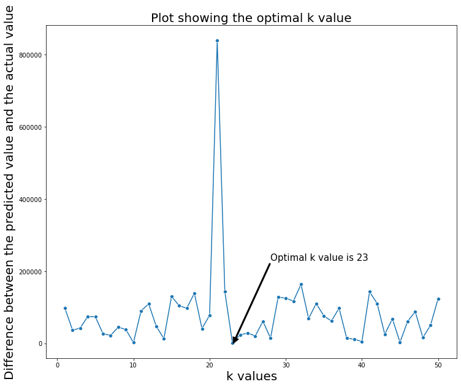

```python
# Line Plot below shows how the k-values and difference between the predicted value and the accessor value of the house.
# It points to the optimal k value.

fig, ax = plt.subplots(figsize=(12, 10))

axes = sns.lineplot(x = knn_results_difference.keys(),
                    y = knn_results_difference.values(),
             ax = ax,
            marker='o')

axes.set_title('Plot showing the optimal k value', fontsize = 20)
axes.set_xlabel('k values', fontsize = 20)
axes.set_ylabel('Difference between the predicted value and the actual value', fontsize = 20)

axes.annotate(
    f'Optimal k value is {optimal_k_value}',
     xy=(optimal_k_value+0.1, 0.5), xytext=(28, 230000),
     fontsize = 15,
    arrowprops=dict(
        width=2,
        headwidth=10,
        headlength=10,
        color='black'
    )
)
```

### Explanation to Question - 2.2 Test your KNN function - How do your predictions perform relative to the Accessor's valuation as you try different values of k.

Answer = I have taken the difference between the predictor value and the accessor value in order to find optimal k value as that would give me the k-value where the predictor value is closest to the true value (Accessor Value). As the k-value is changed from 1 to 50, we see the difference between the predictor value and the accessor value changes not in linear fashion and k=23 has the least difference between predictor value and the accessor value.

## Part III: Ethics Review

Whenever we are modeling our data, it's critical that we take time to consider the impact our algorithms have on people's lives.

### 3.0 (5 pts)

Write a short paragraph that addresses the following questions. No code is required.

1. Describe one possible source of bias that exist might exist in this dataset and impact our estimated valuation?
2. What potential harm could arise due to how our knn regression algorithm works? For example, what if *k* is too low or too high? What impact can outliers have? Would it make sense to normalize (e.g. standardize our values between 0 and 1) for our data points (sqft, age, basement) before calculating Euclidean Distance?
3. Should we have an appeal process for people that may be harmed by the results of our model?

#### Answer

##### 1. Describe one possible source of bias that exist might exist in this dataset and impact our estimated valuation?

Answer = There are some cheaper houses in the expensive areas and there are some expensive houses in the cheaper areas based on the code and output below. You could see that as below as there is a overlap of price between a costiler area and a cheaper area. This indicates there could be bias if you just go with the neighbourhood.

```python
all_data_filt1 = all_data[all_data['nh'] == 107]
all_data_filt1_min = all_data_filt1['total_actual_val'].min()
all_data_filt1_min
```

```
680700
```

```python
all_data_filt1_max = all_data_filt1['total_actual_val'].max()
all_data_filt1_max
```

```
6562900
```

```python
all_data_filt2 = all_data[all_data['nh'] == 940]
all_data_filt2_min = all_data_filt2['total_actual_val'].min()
all_data_filt2_min
```

```
54520
```

```python
all_data_filt2_max = all_data_filt2['total_actual_val'].max()
all_data_filt2_max
```

```
1872500
```

#### 2. What potential harm could arise due to how our knn regression algorithm works?

##### (a). For example, what if k is too low or too high?

##### (b). What impact can outliers have? Would it make sense to normalize (e.g. standardize our values between 0 and 1) for our data points (sqft, age, basement) before calculating Euclidean Distance?

Answer = If the value of 'k' is small then it causes Low Bias, High variance - overfitting of the model. If 'k' is very large then it leads to High Bias, Low variance - underfitting of the model. The optimal K value can be modeled in different ways but I have selected the way where the optimal k-value is the minimum difference between the predicted value of the house (price) and the accessor value of the house (total_actual_val).

Outliers can impact the Euclidean Distance values and that could impact the mean of the prices so it would make sense to normalize (e.g. standardize our values between 0 and 1) for our data points (sqft, age, basement) before calculating Euclidean Distance.

Answer = If the KNN algorithm is not perfect, it could impact the predicted value of the house and that could impact the sale of the house.

THE END